# Data retrieval techniques

*Introduction to Bioinformatics - Module 2*

Nina Norgren

## Retrieve from remote server

- **scp (Secure Copy)** - Safely transfer files between local and remote systems
- **ssh (Secure Shell)** - Gain secure remote access to servers, facilitating command-line operations and file transfers

## Retrieve from remote server

- **scp (Secure Copy)** - Safely transfer files between local and remote systems
- **ssh (Secure Shell)** - Gain secure remote access to servers, facilitating command-line operations and file transfers

## Retrieve from remote server

**Local**: your own computer  
**Remote**: a remote system, often a server located elsewhere

```
scp <file to copy> <copy location>
```

System will prompt for password unless SSH keys set up

## Retrieve from remote server

**Local**: your own computer  
**Remote**: a remote system, often a server located elsewhere

From local to remote:

```
scp myfile.txt remoteuser@remotehost:/remdir/
```

**remoteuser**: The username of the remote host  
**remotehost**: The IP address or hostname of the remote host  
**/remdir**: The directory on the remote machine

## Retrieve from remote server

**Local**: your own computer  
**Remote**: a remote system, often a server located elsewhere

From remote to local:

```
scp remoteuser@remotehost:/remdir/file.txt .
```

( the **.** means the current directory)

## Retrieve from remote server

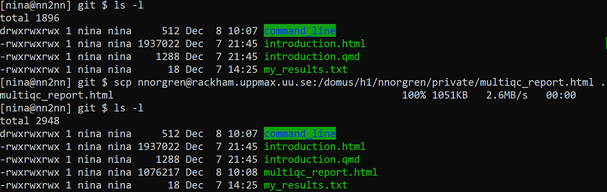

## Retrieve from the web

- **wget** - A command that retrieves files from the web

```
wget <source file>
```

## Retrieve from the web

- **wget** - A command that retrieves files from the web

```
wget <source file>
```

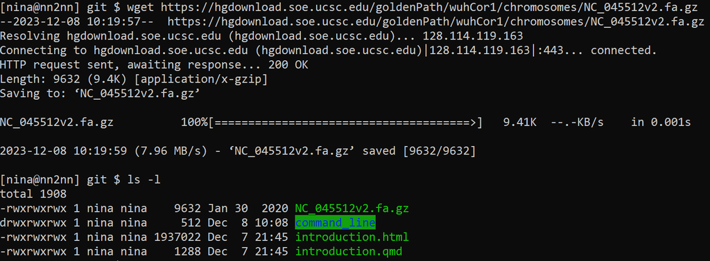

## Summary

- **scp (Secure Copy)** - Transfer files between local and remote systems
- **wget** - A command that retrieves files from the web